# Parental loss: a global perspective

Exploratory data analysis for PAA abstract

```r
## Load packages ---------------------------------------------------------------

## Install/load packages
packages <- c("tidyverse", "ggplot2", "here", "viridis")
for(p in packages){
    if(!require(p,character.only = TRUE)) install.packages(p)
    library(p,character.only = TRUE)
}



## Functions -------------------------------------------------------------------

## Script containing the functions computing
## the main elements required to run the kin dynamics



## Load data -------------------------------------------------------------------

df_birth = readRDS(here("data", "df_birth_example_countries.rda"))

df_results <- readRDS(here("data", "df_results.rda")) |>
  mutate(
    ## Improve plotting
    ctry = ifelse(ctry == "United States of America", "USA", ctry)
    )
```

## Notes to readers:

- Antonino and Ben extracted and formatted GBD and UNWPP data, respectively.
- GBD level 2 causes are currently considered (21 causes).
- Median scenario are considered from UNWPP and GBD estimates.
- Report based on a sample of six countries (Afghanistan, China, Germany, Mexico, Senegal, and USA). It was quicker to run the analyses, and made it possible to share data sets on Github.
- Currently, the model assumes that males have the same fertility rates as females.
- Uncertainty around estimates is not considered and not modeled. Adding it would require substantial coding and running time (big arrays are involved to code the kin dynamics).
- UNWPP and GBD data ranges from 1950 to 2022 and from 1990 to 2019, respectively. Thus, cause-specific causes of death are not considered before 1990.
- In 1950, we assumed a stable population which might have an impact on the parent’s age distribution. Hence, for plots focusing on children (i.e. individuals aged less than 18 years old), we plotted the years 1970-2019 (from 1968 onward, the stable population assumption is not playing a role anymore when focusing on individuals aged less than 18 years old).
- Results are from a period perspective (implied rescaling the number of parent death).

## Preliminary results

Differential in mortality between sexes is visible in Figure 1: fathers are lost earlier. Curves converge to left-skewed normal distributions as time passes. Afghan children lose their fathers at younger ages relative to other countries in recent years.

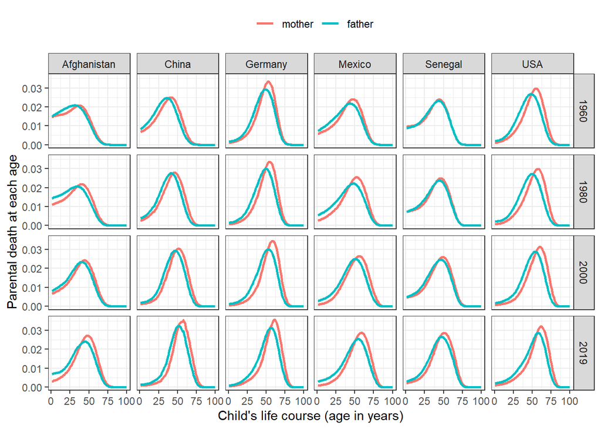

Figure 1: Parental death by parent sex at individual level across selected countries and years - sex comparison

```r
fig.years = c(seq(1960, 2000, 20), 2019)

df_results |>
    filter(
        ## model assumes parent alive at birth of child
        age > 0,
        year %in% fig.years
        ) |>
    ## Sum over all causes of death
    group_by(
      ctry, year, age, sex
      ) |>
    summarise(
      N = sum(N)
      ) |>
    ungroup() |>
    ggplot(aes(x = age, y = N, col = sex)) +
    facet_grid(year ~ ctry) +
    geom_line(linewidth = 1) +
    theme_bw() +
    theme(legend.position = "top",
          legend.title = element_blank()) +
    labs(y = "Parental death at each age",
         x = "Child's life course (age in years)")
```

Convergence in parental death at young ages as time passes, highly visible for Senegal and Afghanistan. Improvement is higher for mother than for father in Afghanistan (Figure 2).

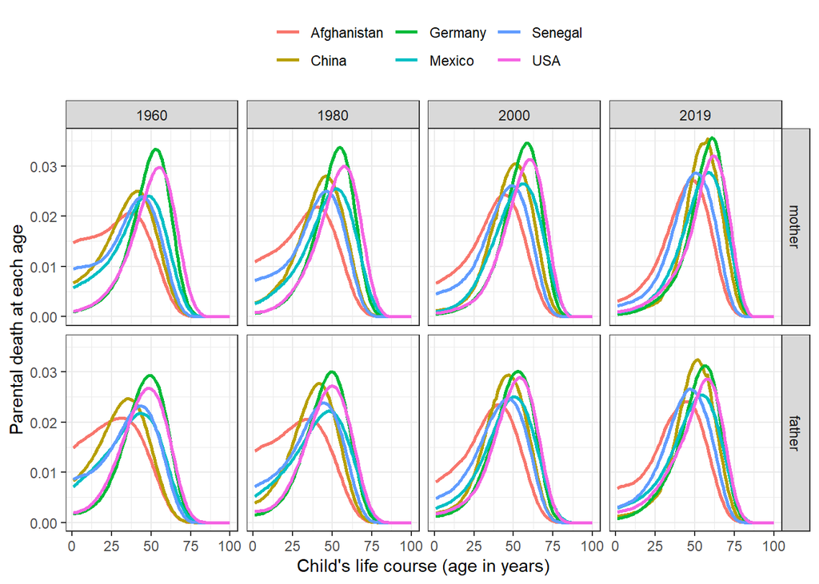

Figure 2: Parental death by parent sex at individual level across selected countries and years - country comparison

```r
fig.years = c(seq(1960, 2000, 20), 2019)

df_results |>
    filter(
        ## model assumes parent alive at birth of child
        age > 0,
        year %in% fig.years
        ) |>
    ## Sum over all causes of death
    group_by(
      ctry, year, age, sex
      ) |>
    summarise(
      N = sum(N)
      ) |>
    ungroup() |>
    ggplot(aes(x = age, y = N, col = ctry)) +
    facet_grid(sex ~ year) +
    geom_line(linewidth = 1) +
    theme_bw() +
    theme(legend.position = "top",
          legend.title = element_blank()) +
    labs(y = "Parental death at each age",
         x = "Child's life course (age in years)")
```

The number of children aged less than 18 years old losing a mother/father over the years (Figure 3). Population growth makes the interpretation of this figure difficult (i.e. Senegal). See Figure 4 for percentages instead of absolute numbers.

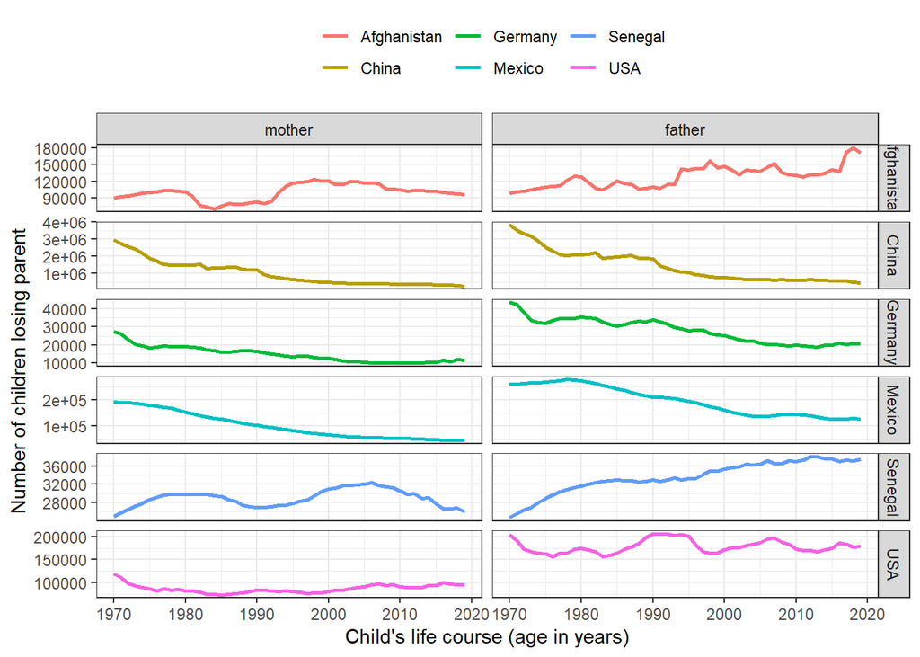

Figure 3: Number of children aged <18 years old bereaved across selected countries and years

```r
## cod data available from year 1990
## !! years 1950  to 1990, assumed causes where
## having equal prob of dying !!
df_results |>
    filter(
      ## assume stable population in 1950 but focus on children
      ## aged < 18 yo, so good to focus on years > 1968
      year >= 1970,
      ## model assumes parent alive at birth of child
      age > 0,
      ## focus on children aged < 18
      age < 18
      ) |>
  ## Sum nber of children losing parent from
  ## all different causes over ages 1 to 17 yo
  group_by(
    ctry, year, sex
    ) |>
  summarise(
    clp = sum(clp)
    ) |>
  ungroup() |>
  ggplot(aes(x = year, y = clp, col = ctry)) +
  facet_grid(ctry ~ sex,
             scales = "free_y") +
  geom_line(linewidth = 1) +
  theme_bw() +
  theme(legend.position = "top",
        legend.title = element_blank()) +
  labs(y = "Number of children losing parent",
       x = "Child's life course (age in years)")
```

It is interesting to compare the percentage of born children losing a parent according to the parent sex (Figure 4). In the year 2020, the disparity in the percentage of born children losing a father is higher compared to the one of losing a mother (i.e USA with drugs epidemic killing young men).

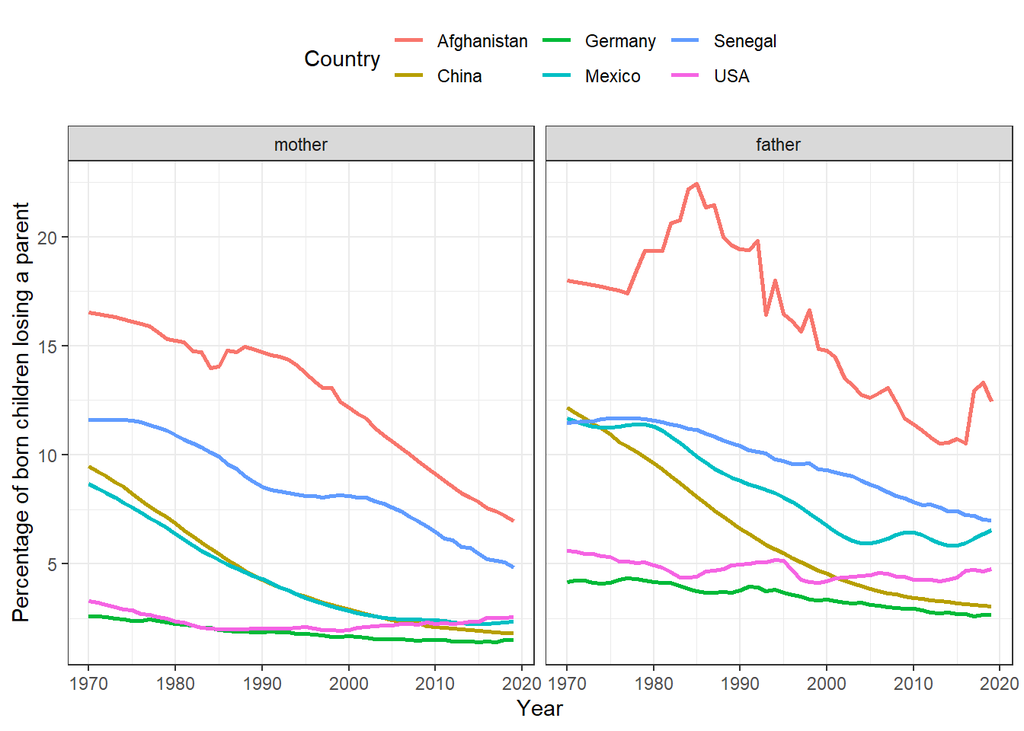

Figure 4: Share of children bereaved across selected countries and years

```r
## cod data available from year 1990
## !! years 1950  to 1990, assumed causes where
## having equal prob of dying !!
df_results |>
    filter(
        ## assume stable population in 1950 but focus on children
        ## aged < 18 yo, so good to focus on years > 1968
        year >= 1970,
        ## model assumes parent alive at birth of child
        age > 0,
        ## focus on children aged < 18
        age < 18
        ) |>
    ## Sum prop of born children losing parent from
    ## all different causes over ages 1 to 17 yo
    group_by(
      sex, year, ctry
      ) |>
    summarise(
      perc = sum(perc)
      ) |>
    ungroup() |>
    ggplot(aes(x = year, y = perc, col = ctry)) +
    facet_wrap(~ sex) +
    geom_line(linewidth = 1) +
    theme_bw() +
    theme(legend.position = "top") +
    labs(y = "Percentage of born children losing a parent",
         x = "Year",
         col = "Country")
```

Cardiovascular diseases makes it hard to interpet Figure 5. See Figure 6 for the same plot focusing on the deadliest causes of death except cardiovascular diseases.

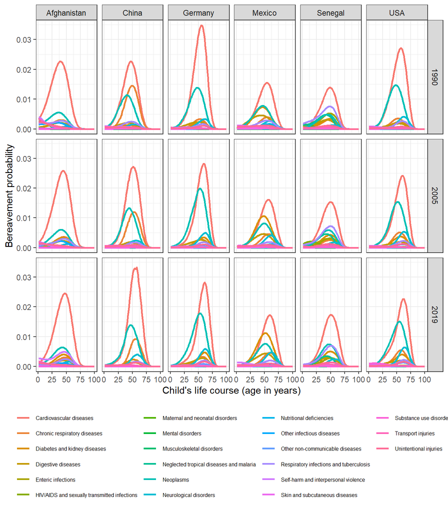

Figure 5: Cause-specific probability of losing at least one parent across selected countries and years

```r
## cod data available from year 1990
## !! years 1950  to 1990, assumed causes where
## having equal prob of dying !!
fig.years = c(1990, 2005, 2019)

df_results |>
  ## Get outputs for both parents combined
  ## (= losing at least one parent)
  ## Sum death over parent sex
    group_by(
        ctry, year, cause, age
        ) |>
    summarise(
        N = sum(N)
        ) |>
    ungroup() |>
    mutate(
        ## Bereavement prob of losing >= 1 parent
        prob_ber = 1 - (1 - (N / 2))^2
    ) |>
  filter(
    ## model assumes parent alive at birth of child
    age > 0,
    year %in% fig.years
    ) |>
    ggplot(aes(x = age, y = prob_ber, col = cause)) +
    facet_grid(year ~ ctry) +
    geom_line(linewidth = 1) +
    theme_bw() +
  theme(legend.position = "bottom",
        legend.title = element_blank(),
        legend.text = element_text(size = 6)) +
  guides(color = guide_legend(override.aes = list(size = 1), ncol = 4, nrow = 6)) +
  labs(y = "Bereavement probability",
         x = "Child's life course (age in years)")
```

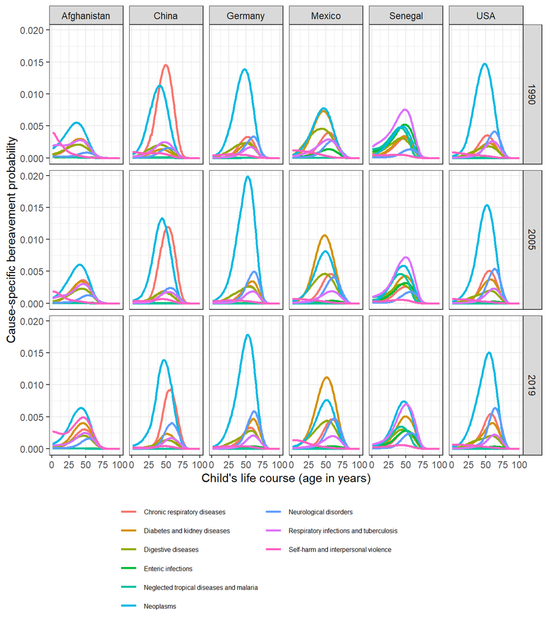

Figure 6: Cause-specific probability of losing at least one parent across selected countries and years - deadliest causes without cardiovascular diseases

```r
## cod data available from year 1990
## !! years 1950  to 1990, assumed causes where
## having equal prob of dying !!
fig.years = c(1990, 2005, 2019)

## Select causes that have a summed bereavement prob
## over the ages > 0.1
deadliest_causes <- df_results |>
    ## Get outputs for both parents combined
  ## (= losing at least one parent)
  ## Sum death over parent sex
    group_by(
        ctry, year, cause, age,
        ) |>
    summarise(
        N = sum(N)
        ) |>
    ungroup() |>
    filter(
    ## model assumes parent alive at birth of child
    age > 0,
    year %in% fig.years
    ) |>
  group_by(ctry, year, cause) |>
  mutate(cumN = cumsum(N)) |>
  ungroup() |>
  mutate(prob_ber = 1 - (1 - (cumN/2))^2) |>
  filter(age == 100) |>
  filter(prob_ber >= 0.1) |>
  pull(cause) |>
  unique()

df_results |>
  ## Get outputs for both parents combined
  ## (= losing at least one parent)
  ## Sum death over parent sex
    group_by(
        ctry, year, cause, age
        ) |>
    summarise(
        N = sum(N)
        ) |>
    ungroup() |>
    mutate(
        ## Bereavement prob of losing >= 1 parent
        prob_ber = 1 - (1 - (N / 2))^2
    ) |>
  filter(
    ## model assumes parent alive at birth of child
    age > 0,
    year %in% fig.years,
    cause != "Cardiovascular diseases",
    cause %in% deadliest_causes
    ) |>
    ggplot(aes(x = age, y = prob_ber, col = cause)) +
    facet_grid(year ~ ctry) +
    geom_line(linewidth = 1) +
    theme_bw() +
  theme(legend.position = "bottom",
        legend.title = element_blank(),
        legend.text = element_text(size = 6)) +
  guides(color = guide_legend(override.aes = list(size = 1), ncol = 4, nrow = 6)) +
  labs(y = "Cause-specific bereavement probability",
         x = "Child's life course (age in years)")
```

```r
## cod data available from year 1990
## !! years 1950  to 1990, assumed causes where
## having equal prob of dying !!
fig.years = c(1990, 2019)

df_results |>
    ## Get outputs for both parents combined
  ## (= losing at least one parent)
  ## Sum death over parent sex
    group_by(
        ctry, year, age
        ) |>
    summarise(
        N = sum(N)
        ) |>
    ungroup() |>
    filter(
    ## model assumes parent alive at birth of child
    age > 0,
    year %in% fig.years
    ) |>
  group_by(year, ctry) |>
  mutate(cumN = cumsum(N)) |>
  ungroup() |>
  mutate(prob_ber = 1 - (1 - (cumN/2))^2) |>
    ggplot(aes(x = age, y = prob_ber)) +
    facet_grid(year ~ ctry) +
    geom_line(linewidth = 1) +
    theme_bw() +
    labs(y = "Cum. bereavement probability",
         x = "Child's life course (age in years)")
```

[output not shown]